## *An Evaluation of Technology Patent Trends*

#### ANLY 511

#### Zhiyu Lin, Jingjie Ma, Thomas P. Malejko, Douglas Post, Nuo Tian, Nuoya Wu

#### Import Required Data Sets

```r
#import the required datasets, check the quality of import
PendingDF <- read.csv('monthly_disposal.csv')
# head(PendingDF)
# str(PendingDF)

MonthlyDF <- read.csv('monthly.csv')
# head(MonthlyDF)
# str(MonthlyDF)
```

*Note: The structure of the imported data sets are not printed to the screen due to large number of variables, which makes for difficult viewing. To view the imported data sets, review the original .csv files.*

```r
#==================================================================================================
# Preliminary Data Cleaning
#==================================================================================================
#remove any incomplete cases from datasets
PendingDF <- PendingDF[complete.cases(PendingDF),]
MonthlyDF <- MonthlyDF[complete.cases(MonthlyDF),]

#create seperate dataframes for each patent status type, retaining time information
AppliedDF   <- MonthlyDF[,1:49]
PendingDF   <- cbind(MonthlyDF[,1],MonthlyDF[,50:97])
IssuedDF    <- cbind(MonthlyDF[,1],MonthlyDF[,98:145])
AbandonedDF <- cbind(MonthlyDF[,1],MonthlyDF[,146:193])
InUseDF     <- cbind(MonthlyDF[,1],MonthlyDF[,194:241])

##calculate total number of patents for each status type by patent category
#initiliaze empty variables for the loop
Issued_sums = c()
Abandoned_sums = c()
Applied_sums = c()

#sum the number of patents in each category listed by status
for(i in 2:49){
  Applied_sums[i-1] = sum(AppliedDF[,i])
  Issued_sums[i-1] = sum(IssuedDF[,i])
  Abandoned_sums[i-1] = sum(AbandonedDF[,i])
}

#reformat the summed patent information into a dataframe
SumDF <- cbind(Applied_sums,Issued_sums,Abandoned_sums)
pattern <- "app"
General_Names <- gsub(pattern,"",names(AppliedDF)[2:49])
rownames(SumDF) <- General_Names

##the 'Pending' and 'InUse' are continuing lists, so it would make more sense to
##look at monthly changes than their totals

#initialize empty dataframes for storage of generated features
Pending_Change = data.frame()
InUse_Change = data.frame()

#create the monthly change data frames from the information contained in the
#earlier generated data frames
for(j in 1:322){
  for(i in 2:49){
    Pending_Change[j,i-1] = PendingDF[j+1,i] - PendingDF[j,i]
    InUse_Change[j,i-1] = InUseDF[j+1,i] - InUseDF[j,i]
  }
}

#merge this generated information with the original data set
Pending_Change <- cbind(MonthlyDF[2:323,1],Pending_Change)
InUse_Change <- cbind(MonthlyDF[2:323,1],InUse_Change)

#rename the columns in according with the workbook's convention
names(Pending_Change)[2:49] <- General_Names
names(InUse_Change)[2:49] <- General_Names

#combine all datasets into a single dataframe for future analysis
# Patent_Data <- cbind(AppliedDF[2:323,1:49],Pending_Change[,2:49],IssuedDF[2:323,2:49],AbandonedDF[2:323,2:49],InUse_Change[2:323,2:49])

#initialize variables for the loop by extracting the 'Month' as a standalone column in a DF
By_Category <- Pending_Change[,c(1,2)]
By_Category$Agriculture.Food.Textiles..ch. <- NULL
name_list <- c()

#rename first column in all data frames to 'Month' for easier compilation
names(By_Category)[1]<-"Month"
names(AppliedDF)[1] <-"Month"
names(Pending_Change)[1]<-"Month"
names(IssuedDF)[1] <-"Month"
names(AbandonedDF)[1]<-"Month"
names(InUse_Change)[1]<-"Month"

#seperate all data in the DF into seperate DF by patent category
for(j in 2:49){
  name_temp<- c(colnames(AppliedDF)[j], "Pending_Change[, j]", "Issued_Patents[2:323, j]", "Abandoned_Patents[2:323, j]", "InUse_Change[, j]")
  name_list <- append(name_list, name_temp)
  By_Category <- cbind(By_Category, AppliedDF[2:323,j],Pending_Change[,j],IssuedDF[2:323,j],AbandonedDF[2:323,j],InUse_Change[,j])
}

#rename the columns for easier analysis
names(By_Category)[2:241] <- name_list

#export the new dataset to a .csv for future analysis with the generated features
write.csv(By_Category,"Patent.csv")
```

```r
#==================================================================================================
# Refined Data Set Cleaning (Variable Renaming)
#==================================================================================================
#create copy of data frame for future manipulation
PatentDF <- data.frame(By_Category)

#convert 'Month' into a date object (using lubridate package)
PatentDF$Month <- parse_date_time(PatentDF$Month, orders = c("ym"))

#to convert to YYYY-mm format, use PatentDF$Pending_Change...1. <- format(as.Date(PatentDF$Pending_Change...1.), "%Y-%m")

#rename the date column
colnames(PatentDF)[1] <- "Year-Month"

##rename columns (provide cleaner titles)
#rough cleaning for all column names
col_names <- c()

for (i in colnames(PatentDF)) {
  j <- strsplit(as.character(i), split = "\\.")[[1]][1]
  col_names <- append(col_names, j)
}

#manually modify unclear column names for clarity
col_names <- replace(col_names, 2, "AgFoodTextiles")
col_names <- replace(col_names, 27, "Chemical_Misc")
col_names <- replace(col_names, 37, "Comp_Hardware_Software")
col_names <- replace(col_names, 42, "Comp_Peripherals")
col_names <- replace(col_names, 47, "Info_Storage")
col_names <- replace(col_names, 52, "Business_Software")
col_names <- replace(col_names, 72, "Medical_Misc")
col_names <- replace(col_names, 76, "Elec_Devices")
col_names <- replace(col_names, 82, "Elec_Lighting")
col_names <- replace(col_names, 102, "Semiconductors")
col_names <- replace(col_names, 107, "Elec_Misc")
col_names <- replace(col_names, 137, "Mech_Misc")
col_names <- replace(col_names, 182, "Other_Misc")
col_names <- replace(col_names, 187, "Not_Classified")
col_names <- replace(col_names, 192, "Missing")
col_names <- replace(col_names, 202, "Chemical_Cat")
col_names <- replace(col_names, 207, "InfoTech_Cat")
col_names <- replace(col_names, 212, "Drug_Med_Cat")
col_names <- replace(col_names, 217, "Elec_Cat")
col_names <- replace(col_names, 222, "Mechanical_Cat")
col_names <- replace(col_names, 227, "Others_Cat")
col_names <- replace(col_names, 232, "NotClassified_Cat")
col_names <- replace(col_names, 237, "Missing_Cat")

colnames(PatentDF) <- col_names

#save this updated data frame to a .csv for future use.
write.csv(PatentDF,"Patent_Cleaned.csv")
```

### ==================================================================================================

### Exploratory Data Analysis

### ==================================================================================================

#### EDA Study 1: Patent Wait Times Development Script

*Not run in .rmd due to extensively long run time* *Generated file (PatentWaitTimes.csv) can be viewed in the containing folder*

```r
#create local copy of data frame for this analysis
Pending_Stats <- data.frame(By_Category)

#create a function to evaluate average patent wait time
average_wait_time <- function(yearmonth,patentclass){
  change = c()
  for(l in 1:(nrow(Pending_Stats[Pending_Stats$appl_month == yearmonth,])-1)){
    change[l] <- Pending_Stats[Pending_Stats$appl_month == yearmonth,][patentclass][l,] - Pending_Stats[Pending_Stats$appl_month == yearmonth,][patentclass][l+1,]
  }
  sum(Pending_Stats[Pending_Stats$appl_month == yearmonth,]["months_since_filing"]* change)/Pending_Stats[Pending_Stats$appl_month == yearmonth,][patentclass][1,]
}

patentcat <- names(Pending_Stats)[4:51]
AverageDecisionTime1 <- data.frame()

for(i in 47:48){
  for(j in 1:322){
    AverageDecisionTime1[j,i] <- average_wait_time(Patent_Category[j,1],patentcat[i])
  }
}

# Create a clean and well named csv, so I never have to run that again.
ADT <- read.csv("patentWaitTimes.csv")
ADT <- ADT[,2:49]
names(ADT) <- General_Names
ADT <- cbind(InUse_Change[,1], ADT)
names(ADT)[1] <- 'month'
ADT[,1] <- as.character(ADT[,1])
write.csv(ADT, "PatentWaitTimes.csv")

# For all the time after the end of 2005 a lot of the patent categories have patents still pending to the end of the observation
# period, December 2014. Lets only look at the months from March 1987 - December 2005.

AverageDecisionTime <- ADT[1:226,]

A.D.T.Chem <- (sum(AverageDecisionTime[,2:7])/nrow(AverageDecisionTime))/6
A.D.T.CC <- (sum(AverageDecisionTime[,8:12])/nrow(AverageDecisionTime))/5
A.D.T.DrMe <- (sum(AverageDecisionTime[,13:16])/nrow(AverageDecisionTime))/4
A.D.T.ElE <- (sum(AverageDecisionTime[,17:23])/nrow(AverageDecisionTime))/7
A.D.T.Mech <- (sum(AverageDecisionTime[,24:29])/nrow(AverageDecisionTime))/6
A.D.T.OTHR <- (sum(AverageDecisionTime[,30:38])/nrow(AverageDecisionTime))/9

Totals <- cbind(c(A.D.T.Chem),c(A.D.T.CC),c(A.D.T.DrMe),c(A.D.T.ElE),c(A.D.T.Mech),c(A.D.T.OTHR))

barplot(Totals[1,], space = 2,
        legend.text=c('Chemical','Computer and Communications','Drugs and Medicine','Electrical and ','Mechanical','Other'),
        xlim = c(0,40), col = rainbow(6), axes = TRUE, horiz = TRUE, main = "Mean Months Pending from Mar. 1987 - Dec. 2005")

Years <- c('1988','1989','1990','1991','1992','1993','1994','1995','1996','1997','1998','1999','2000','2001',
           '2002','2003','2004','2005')

AFT <- matrix(ncol = 37, nrow = 18)
X <- c()
for(h in 2:38){
  for(j in 1:18){
    for(i in 1:12){
      X[i] <- as.numeric(ADT[ADT$month == paste(years[j],'m',i, sep=""),][h])
    }
    AFT[j,h-1] <- mean(X)
  }
}

AFT <- data.frame(AFT)
colnames(AFT) <- General_Names[1:37]
rownames(AFT) <- years
CH <- (AFT[,1] + AFT[,2] + AFT[,3] + AFT[,4] + AFT[,5]+AFT[,6])/5
C_C <- (AFT[,7]+AFT[,8]+AFT[,9]+AFT[,10]+AFT[,11])/5
D_M <- (AFT[,12]+AFT[,13]+AFT[,14]+AFT[,15])/4
E_E <- (AFT[,22]+AFT[,16]+AFT[,17]+AFT[,18]+AFT[,19]+AFT[,20]+AFT[,21])/7
MECH <- (AFT[,23]+AFT[,24]+AFT[,25]+AFT[,26]+AFT[,27]+AFT[,28])/6
Other <- (AFT[,29]+AFT[,30]+AFT[,31]+AFT[,32]+AFT[,33]+AFT[,34]+AFT[,35]+AFT[,36]+AFT[,37])/9

plot.default(Years,CH, bg = 'black', pch = 25, cex = 1.4, type ='b', lwd =2, ylab = "Pending Wait (Months)",
             ylim = c(10,50))
points(Years, C_C, col = 'red', pch = 15, cex = 1.4, type ='b', lwd =2, lty = 2)
points(Years, D_M, col = 'blue', pch = 16, cex = 1.4, type = 'b', lwd = 2, lty = 3)
points(Years, E_E, col = 'green', pch = 17, cex = 1.4, type = 'b', lwd = 2, lty = 4)
points(Years, MECH, col = 'gray', pch = 18, cex = 1.4, type = 'b', lwd = 2, lty = 5)
points(Years, Other, col = 'yellow', bg = 'yellow', pch = 23, cex = 1.4, type = 'b', lwd = 2, lty = 6)
legend(1988, 50, legend = c("Chemical","Computer/Communication", "Drug/Medicine","Electric/","Mechanical","Other"),
       lty = 1:6, pch = c(25,15,16,17,18,23), lwd = 2, col = c('black','red','blue','green','gray','yellow'), cex = 1.1)


CHT <- ggplot(data = AFT, aes(Years, CH, C_C))
CHT + geom_point() + ylab('Chemicals')
CH1 <- ggplot(data = AFT, aes(Years,AFT[,1]))
CH1 + geom_point() + ylab(names(AFT)[1])
CH2 <- ggplot(data = AFT, aes(Years,AFT[,2]))
CH2 + geom_point() + ylab(names(AFT)[2])
CH3 <- ggplot(data = AFT, aes(Years,AFT[,3]))
CH3 + geom_point() + ylab(names(AFT)[3])
CH4 <- ggplot(data = AFT, aes(Years,AFT[,4]))
CH4 + geom_point() + ylab(names(AFT)[4])
CH5 <- ggplot(data = AFT, aes(Years,AFT[,5]))
CH5 + geom_point() + ylab(names(AFT)[5])
```

#### EDA Study 2: Patent Information by Category over Time

```r
#create a list of patent categories
patent_type <- c()

for (i in col_names) {
  if ((which(names(PatentDF)==i)-2)%%5 == 0) {
    patent_type <- append(patent_type, i)
  }
}

#break the larger dataframe into smaller dataframes, sorted by patent type
for (i in patent_type) {
  StartIndex <- which(names(PatentDF)==i)
  StopIndex <- StartIndex + 4
  DF <- PatentDF[StartIndex : StopIndex]
  DF <- cbind(PatentDF[1], DF)
  colnames(DF)[2] <- "Total_Pending"
  assign(paste(i, "DF", sep = ""), DF)
}

#isolate summary patent categories (these are the broad categories [electronics, chemical, etc.])
summary_categories <- patent_type[41:48]
summary_cat_DFlist <- c()

for (i in summary_categories) {
  x <- paste(i, "DF", sep = "")
  summary_cat_DFlist <- append(summary_cat_DFlist, x)
}

#plot Applications Pending v. Abandonded
count <- 1

InitialPlots <- function(i) {
  p <- ggplot(eval(parse(text=i)), aes(x=`Year-Month`, y=Total_Pending)) +
    annotate("rect", xmin=as.POSIXct('1995-01-01'), xmax=as.POSIXct('2000-03-01'), ymin=0, ymax=Inf, fill='deepskyblue1', alpha=.5) + #dotcom bubble
    annotate("rect", xmin=as.POSIXct('2000-03-11'), xmax=as.POSIXct('2004-10-01'), ymin=0, ymax=Inf, fill='red1', alpha=.5) +         #dotcom bust
    annotate("rect", xmin=as.POSIXct('2001-01-01'), xmax=as.POSIXct('2006-01-01'), ymin=0, ymax=Inf, fill='springgreen3', alpha=.5) + #housing/finacial bubble
    annotate("rect", xmin=as.POSIXct('2008-10-01'), xmax=as.POSIXct('2012-01-01'), ymin=0, ymax=Inf, fill='red1', alpha=.5) +         #housing/finacial bust
    geom_point() +
    geom_point(aes(y = Abandoned_Patents), colour="black", pch=21, size=1.5) +
    xlab('Year') +
    ylab('Number of Patents') +
    ggtitle(paste('Pending Patents for', i), subtitle = "Applications Pending(Solid) v. Abandoned (Hollow)\nBlue and green areas are 'Dot Com' and 'Housing' Bubbles\nRed areas are the assc. busts.")

  name <- paste("plot_", i,".png", sep = "")

  ggsave(name, p)

  return(assign(paste("plot_", i, sep = ""), p))

}

plot_list <- lapply(summary_cat_DFlist, InitialPlots)
#plot multiple ggplots onto the same chart
g <- arrangeGrob(grobs=plot_list[1:6], nrow=2)
aspect <- 2.5
ggsave('Patents Pending v Abandonded.png', g, height = 7, width =7*aspect)
```

#### Descriptive Statistics

*Note: The generated output was suppressed for this chunk due to the extensive number of variables. To view the output from this section, review the ‘ANLY511_Final Project_SummaryStats.csv’ file.*

```r
#create a local copy of the data frame for analysis in this section
df <- data.frame(PatentDF)

#create a function to reformat the standard descriptive statistics function in R
#into a more readable format for this research
SumStats <- function(df){
  # Get R built-in the Summary Statistics
  All_Vars <- summary(df[,2:44])
  # Create DataFrame for new Summary Stats
  SmmryDF <- data.frame(matrix(nrow = 43,ncol = 5))
  # Enter in the data from buit-in Stats
  SmmryDF[,1] <- All_Vars[1,]
  SmmryDF[,2] <- All_Vars[3,]
  SmmryDF[,3] <- All_Vars[4,]
  SmmryDF[,5] <- All_Vars[6,]
  # Remove Word Labels in cells
  wordsToRemove <- c('Min.   :','Median :','Mean   :','Max.   :')
  SmmryDF <- as.data.frame(sapply(SmmryDF, function(x)
    gsub(paste(wordsToRemove, collapse = '|'), '', x)))
  # Convert Now Factor Variables to numeric
  SmmryDF %>% mutate_if(is.factor, as.character) -> SmmryDF
  SmmryDF %>% mutate_if(is.character, as.numeric) -> SmmryDF
  # Enter in Standard Deviation
  for(i in 1:43){
    SmmryDF[i,4] <- round(sd(df[,i]),digits = 4)
  }
  # Rename the Summary Stats
  names(SmmryDF) <-  c('Minimum','Median','Mean','Std. Dev.','Maximum')
  # Name the Rows after the Patent Names
  row.names(SmmryDF) <- names(df)[2:44]
  # Write to a csv
  write.csv(SmmryDF,'ANLY511_Final Project_SummaryStats.csv')
  return(SmmryDF)
}

# SumStats(df)
```

### ==================================================================================================

### ==================================================================================================

#### Observation #1: Computer and Electronic Applications Increase Post-‘Dot Com’ Bubble (1996)

```r
#create local copy of the principle data frame for future analysis
df <- data.frame(Elec_CatDF)

#confirm structure of data frame
head(df)
```

```
##   Year.Month Total_Pending Pending_Change Issued_Patents Abandoned_Patents
## 1 1987-03-01          1720           -365           1678               403
## 2 1987-04-01          1512            -43           1212               341
## 3 1987-05-01          1555            133           1041               377
## 4 1987-06-01          1589           -452           1672               365
## 5 1987-07-01          1539           -137           1213               459
## 6 1987-08-01          1369           -325           1318               376
##   InUse_Change
## 1          438
## 2          246
## 3          -26
## 4          739
## 5          492
## 6          199
```

```r
str(df)
```

```
## 'data.frame':    322 obs. of  6 variables:
##  $ Year.Month       : POSIXct, format: "1987-03-01" "1987-04-01" ...
##  $ Total_Pending    : int  1720 1512 1555 1589 1539 1369 1561 1609 1550 1746 ...
##  $ Pending_Change   : int  -365 -43 133 -452 -137 -325 -337 -92 134 -10 ...
##  $ Issued_Patents   : int  1678 1212 1041 1672 1213 1318 1461 1259 1036 1346 ...
##  $ Abandoned_Patents: int  403 341 377 365 459 376 434 440 374 410 ...
##  $ InUse_Change     : int  438 246 -26 739 492 199 517 117 -566 -65 ...
```

```r
#seperate month and year into seperate columns
colnames(df)[1] <- 'Date'
df$Month <- format(as.Date(df$Date), '%m')
df$Year <- format(as.Date(df$Date), '%Y')

#seperate the df into pre- and post-1996 data frames
total_pending_before_1996 <- df %>% filter(Year <= 1996) %>% select(Total_Pending)
total_pending_after_1996 <- df %>% filter(Year > 1996) %>% select(Total_Pending)

#generate boxplot to visually compare differences
#file to save plot to
png('Prop1_Elec Patents Pending c 1996.png', width = 750, height = 750)
boxplot(total_pending_before_1996$Total_Pending, total_pending_after_1996$Total_Pending,
        ylab  = 'Number of Patents',
        main = 'Electronics Patents Before/After 1996')
dev.off()
```

```r
# use t-test to check total number of patent applications pending before and after 1996
print(t.test(total_pending_before_1996, total_pending_after_1996))
```

```
##
##  Welch Two Sample t-test
##
## data:  total_pending_before_1996 and total_pending_after_1996
## t = -28.903, df = 295.93, p-value < 2.2e-16
## alternative hypothesis: true difference in means is not equal to 0
## 95 percent confidence interval:
##  -3023.134 -2637.685
## sample estimates:
## mean of x mean of y
##  2167.703  4998.113
```

```r
# permutation test
perm_df_before_1996 <- cbind(total_pending_before_1996$Total_Pending,rep(1,length(total_pending_before_1996)))
perm_df_after_1996 <- cbind(total_pending_after_1996$Total_Pending,rep(0,length(total_pending_after_1996)))
perm_df <- rbind(perm_df_before_1996,perm_df_after_1996)
colnames(perm_df) <- c("Total_Pending","Group")
perm_df <- as.data.frame(perm_df)
head(perm_df)
```

```
##   Total_Pending Group
## 1          1720     1
## 2          1512     1
## 3          1555     1
## 4          1589     1
## 5          1539     1
## 6          1369     1
```

```r
table(perm_df$Group)
```

```
##
##   0   1
## 204 118
```

```r
aggregate(Total_Pending ~ Group, data = perm_df, FUN = mean)
```

```
##   Group Total_Pending
## 1     0      4998.113
## 2     1      2167.703
```

```r
perm.test <- function(mydf){
  agg <- aggregate(Total_Pending ~ Group, data = mydf, FUN = mean)
  return(agg$Total_Pending[1] - agg$Total_Pending[2])
}

perm.test(perm_df)
```

```
## [1] 2830.409
```

```r
permute.sample <- function(mydf){
  df.permute <- mydf
  n <- length(mydf[,1])
  df.permute$Group <- mydf$Group[sample(n,n)]
  return(perm.test(df.permute))
}

permute.sample(perm_df)
```

```
## [1] -205.904
```

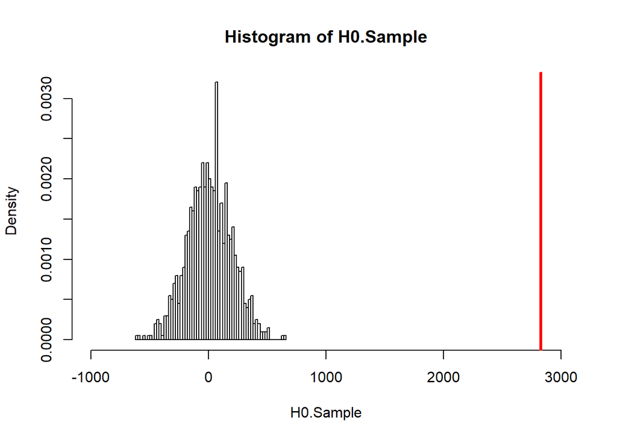

```r
N <- 1000
H0.Sample <- replicate(N, permute.sample(perm_df))
hist(H0.Sample, prob  = T, breaks = 50,xlim = c(-1000,3000))
abline (v = perm.test(perm_df), col = 2, lwd = 3)
```

#### Observation #2: Semi-Conductor Increase Post-‘Dot Com’ Bubble (1996)

```r
#create local copy of data frame for the analysis
df2 <- data.frame(SemiconductorsDF)

#confirm structure of the data frame
head(SemiconductorsDF)
```

```
##   Year-Month Total_Pending Pending_Change Issued_Patents Abandoned_Patents
## 1 1987-03-01           136             -5            136                 5
## 2 1987-04-01           107             22             83                 0
## 3 1987-05-01           137             37             95                 5
## 4 1987-06-01           145             -2            143                 4
## 5 1987-07-01           131             22            107                 2
## 6 1987-08-01           100            -16            110                 6
##   InUse_Change
## 1           90
## 2           28
## 3           46
## 4          105
## 5           75
## 6           68
```

```r
#seperate month and year into seperate columns
colnames(df2)[1] <- 'Date'
df2$Month <- format(as.Date(df2$Date), '%m')
df2$Year <- format(as.Date(df2$Date), '%Y')

#seperate the df into pre- and post-1996 data frames
semi_total_before_1996 <- df2 %>% filter(Year <= 1996) %>% select(Total_Pending)
semi_total_after_1996 <- df2 %>% filter(Year > 1996) %>% select(Total_Pending)

#generate boxplot to visually compare differences
#file to save plot to
png('Prop2_SemiConduct Patents Pending c 1996.png', width = 750, height = 750)
boxplot(semi_total_before_1996$Total_Pending, semi_total_after_1996$Total_Pending,
        ylab  = 'Number of Patents',
        main = 'Electronics Patents Before/After 1996')
dev.off()
```

```r
# use t-test to check total number of patent applications pending before and after 1996
print(t.test(semi_total_before_1996$Total_Pending, semi_total_after_1996$Total_Pending))
```

```
##
##  Welch Two Sample t-test
##
## data:  semi_total_before_1996$Total_Pending and semi_total_after_1996$Total_Pending
## t = -34.662, df = 319.6, p-value < 2.2e-16
## alternative hypothesis: true difference in means is not equal to 0
## 95 percent confidence interval:
##  -992.3419 -885.7407
## sample estimates:
## mean of x mean of y
##  323.1695 1262.2108
```

```r
# permutation test
perm_semi_before_1996 <- cbind(semi_total_before_1996$Total_Pending,rep(1,length(semi_total_before_1996)))
perm_semi_after_1996 <- cbind(semi_total_after_1996$Total_Pending,rep(0,length(semi_total_after_1996)))
perm_df_2 <- rbind(perm_semi_before_1996,perm_semi_after_1996)
colnames(perm_df_2) <- c("Total_Pending","Group")
perm_df_2 = as.data.frame(perm_df_2)
head(perm_df_2)
```

```
##   Total_Pending Group
## 1           136     1
## 2           107     1
## 3           137     1
## 4           145     1
## 5           131     1
## 6           100     1
```

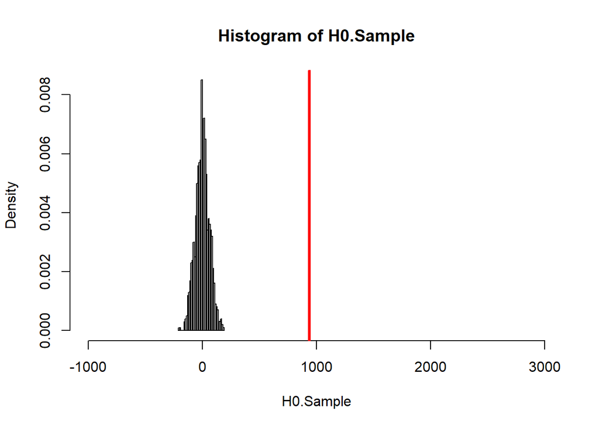

```r
N <- 1000
H0.Sample <- replicate(N, permute.sample(perm_df_2))
hist(H0.Sample, prob = T, breaks = 50,xlim = c(-1000,3000))
abline (v = perm.test(perm_df_2), col = 2, lwd = 3)
```

#### Observation #3: Increase of Abandonded Computer & Electronics Patents before/after 2002-10-09 (Dot Com Bust)

```r
#create local copy of the data frame for further analysis
df <- data.frame(Elec_CatDF)

colnames(df)[1] <- 'Date'
df$Month <- format(as.Date(df$Date), '%m')
df$Year <- format(as.Date(df$Date), '%Y')

#compute the rate of patent abandonment
elec_df <- df %>% mutate(Abandon_Rate = Abandoned_Patents / Issued_Patents )

#visualize the new variable
png('Prop3_Elec Patents Abn c 2001_Scatter.png', width = 750, height = 750)
plot(elec_df$Date, elec_df$Abandon_Rate,
     main = 'Abandon Rate', xlab = 'Time', ylab = 'Abandon Rate')
dev.off()
```

```r
#split the data frame before and after Dot Com Bust
abn_before_2002 <- elec_df %>% filter(Date <= as.Date('2002-10-09')) %>% select(Abandon_Rate)
abn_after_2002 <- elec_df %>% filter(Date > as.Date('2002-10-09')) %>% select(Abandon_Rate)

#determine significance of difference between the two periods
print(t.test(abn_before_2002, abn_after_2002))
```

```
##
##  Welch Two Sample t-test
##
## data:  abn_before_2002 and abn_after_2002
## t = -3.6833, df = 233.86, p-value = 0.0002861
## alternative hypothesis: true difference in means is not equal to 0
## 95 percent confidence interval:
##  -0.06112226 -0.01852140
## sample estimates:
## mean of x mean of y
## 0.2907080 0.3305298
```

```r
#split the data frame before and after Financial Services Bust
abn_before_2007 <- elec_df %>% filter(Date <= as.Date('2007-10-09')) %>% select(Abandon_Rate)
abn_after_2007 <- elec_df %>% filter(Date > as.Date('2007-10-09')) %>% select(Abandon_Rate)

#determine significance of difference between the two periods
print(t.test(abn_before_2007, abn_after_2007))
```

```
##
##  Welch Two Sample t-test
##
## data:  abn_before_2007 and abn_after_2007
## t = -9.284, df = 102.95, p-value = 2.901e-15
## alternative hypothesis: true difference in means is not equal to 0
## 95 percent confidence interval:
##  -0.13501795 -0.08748599
## sample estimates:
## mean of x mean of y
## 0.2817126 0.3929646
```

```r
##conduct a linear regression of this new variable
elec_df <- elec_df %>% mutate(time_flag_1996 = if_else(Year > 1996, 'After 1996', 'Before 1996'))

# response in this case will be total pending
mod1 <- lm(Total_Pending ~ Pending_Change + Issued_Patents + Abandoned_Patents + InUse_Change + Abandon_Rate + time_flag_1996, data = elec_df)

summary(mod1)
```

```
##
## Call:
## lm(formula = Total_Pending ~ Pending_Change + Issued_Patents +
##     Abandoned_Patents + InUse_Change + Abandon_Rate + time_flag_1996,
##     data = elec_df)
##
## Residuals:
##     Min      1Q  Median      3Q     Max
## -1989.0  -373.7   -49.0   267.4  4674.4
##
## Coefficients:
##                             Estimate Std. Error t value Pr(>|t|)
## (Intercept)                9.197e+02  4.593e+02   2.003  0.04608 *
## Pending_Change             1.108e-03  3.257e-03   0.340  0.73392
## Issued_Patents             1.084e+00  1.940e-01   5.585 5.05e-08 ***
## Abandoned_Patents          1.891e-02  4.459e-01   0.042  0.96621
## InUse_Change              -3.167e-01  1.350e-01  -2.346  0.01962 *
## Abandon_Rate               3.551e+03  1.341e+03   2.647  0.00853 **
## time_flag_1996Before 1996 -1.442e+03  1.178e+02 -12.247  < 2e-16 ***
## ---
## Signif. codes:  0 '***' 0.001 '**' 0.01 '*' 0.05 '.' 0.1 ' ' 1
##
## Residual standard error: 650.9 on 315 degrees of freedom
## Multiple R-squared:  0.8574, Adjusted R-squared:  0.8546
## F-statistic: 315.5 on 6 and 315 DF,  p-value: < 2.2e-16
```

```r
#anova test of the linear model
anova(mod1)
```

```
## Analysis of Variance Table
##
## Response: Total_Pending
##                    Df    Sum Sq   Mean Sq   F value    Pr(>F)
## Pending_Change      1   8003100   8003100   18.8889 1.872e-05 ***
## Issued_Patents      1 697452212 697452212 1646.1232 < 2.2e-16 ***
## Abandoned_Patents   1  32694673  32694673   77.1658 < 2.2e-16 ***
## InUse_Change        1     99043     99043    0.2338    0.6291
## Abandon_Rate        1    343899    343899    0.8117    0.3683
## time_flag_1996      1  63548342  63548342  149.9865 < 2.2e-16 ***
## Residuals         315 133463549    423694
## ---
## Signif. codes:  0 '***' 0.001 '**' 0.01 '*' 0.05 '.' 0.1 ' ' 1
```

```r
# improve the model by removing inuse change and abandon rate
mod2 <- lm(Total_Pending ~ Pending_Change + Issued_Patents + Abandoned_Patents + + time_flag_1996, data = elec_df)

summary(mod2)
```

```
##
## Call:
## lm(formula = Total_Pending ~ Pending_Change + Issued_Patents +
##     Abandoned_Patents + +time_flag_1996, data = elec_df)
##
## Residuals:
##     Min      1Q  Median      3Q     Max
## -1967.2  -383.2   -46.6   285.3  4702.9
##
## Coefficients:
##                             Estimate Std. Error t value Pr(>|t|)
## (Intercept)                2.250e+03  1.627e+02  13.826  < 2e-16 ***
## Pending_Change             2.421e-03  3.268e-03   0.741    0.459
## Issued_Patents             4.558e-01  6.485e-02   7.029 1.28e-11 ***
## Abandoned_Patents          1.277e+00  1.308e-01   9.762  < 2e-16 ***
## time_flag_1996Before 1996 -1.342e+03  1.154e+02 -11.624  < 2e-16 ***
## ---
## Signif. codes:  0 '***' 0.001 '**' 0.01 '*' 0.05 '.' 0.1 ' ' 1
##
## Residual standard error: 660.9 on 317 degrees of freedom
## Multiple R-squared:  0.852,  Adjusted R-squared:  0.8502
## F-statistic: 456.3 on 4 and 317 DF,  p-value: < 2.2e-16
```

```r
#anova test of the linear model
anova(mod1)
```

```
## Analysis of Variance Table
##
## Response: Total_Pending
##                    Df    Sum Sq   Mean Sq   F value    Pr(>F)
## Pending_Change      1   8003100   8003100   18.8889 1.872e-05 ***
## Issued_Patents      1 697452212 697452212 1646.1232 < 2.2e-16 ***
## Abandoned_Patents   1  32694673  32694673   77.1658 < 2.2e-16 ***
## InUse_Change        1     99043     99043    0.2338    0.6291
## Abandon_Rate        1    343899    343899    0.8117    0.3683
## time_flag_1996      1  63548342  63548342  149.9865 < 2.2e-16 ***
## Residuals         315 133463549    423694
## ---
## Signif. codes:  0 '***' 0.001 '**' 0.01 '*' 0.05 '.' 0.1 ' ' 1
```

```r
#since we cannot use log likelihood directly, we will use AIC instead. AIC uses likelihood.
AIC(mod1, mod2)
```

```
##      df      AIC
## mod1  8 5094.798
## mod2  6 5102.599
```

```r
#^still choose mod1 since lower AIC is preferred.
```

```r
#create local copy of the data frame for further analysis
infotechDF <- data.frame(InfoTech_CatDF)

#seperate data into month and year columns
colnames(infotechDF)[1] = 'Date'
infotechDF$Month <- format(as.Date(infotechDF$Date), "%m")
infotechDF$Year <- format(as.Date(infotechDF$Date), "%Y")

#seperate the dataframe by time frame chunks
x1 <- infotechDF %>% filter(as.Date('2001-4-1') <= Date) %>% filter(Date <= as.Date('2003-02-03')) %>% select(Total_Pending) %>%  filter(!is.na(Total_Pending)) %>% unlist()
x2 <- infotechDF %>% filter(Date < as.Date('2001-4-1'))  %>% select(Total_Pending) %>% filter(!is.na(Total_Pending))%>% unlist()
x3 <- infotechDF %>% filter(Date > as.Date('2003-2-1')) %>% select(Total_Pending)  %>% filter(!is.na(Total_Pending))%>% unlist()

# for year before '4-1-2001' and after
boot <- rep(0, 10000)

for (i in 1:10000){
  a <- sample(x1, replace = T)
  b <- sample(x2, replace = T)
  boot[i] <- mean(a) - mean(b)
}

quantile(boot, c(0.025, 0.975))
```

```
##     2.5%    97.5%
## 3447.892 4140.134
```

```r
boot <- rep(0, 10000)

# for year before '2-1-2003' and after
for (i in 1:10000){
  a <- sample(x1, replace = T)
  b <- sample(x2, replace = T)
  boot[i] <- mean(a) - mean(b)
}

quantile(boot, c(0.025, 0.975))
```

```
##     2.5%    97.5%
## 3445.027 4138.977
```